# Camera trap distance sampling workshop

Practical 2 **solution**:  
detection function fitting for the duiker data set

Workshop development group http://workshops.distancesampling.org (CREEM, Univ of St Andrews)https://www.creem.st-andrews.ac.uk  
2022-03-28

# Analysis of camera trapping data using distance sampling

A distance sampling approach to the analysis of camera trapping data offers the potential advantage that individual animal identification is not required. However, accurate animal-to-camera detection distances are required. This requires calibration prior to the survey with images of objects of known size taken at known distances from the camera. See details in Howe, Buckland, Després-Einspenner, & Kühl (2017) for description of the field work and data analysis. Here we present analysis of data from Howe et al. (2017) using the R package `Distance` Miller, Rexstad, Thomas, Marshall, & Laake (2019).

## Data input

A data set for recording of detections during *peak activity* are included in the `Distance` package. Examine the `DuikerCameraTraps` described in the data repository Howe, Buckland, Després-Einspenner, & Kühl (2018).

```r
library(Distance)
data("DuikerCameraTraps")
```

## Exploratory Data Analysis

A quick summary of the data set including: How many camera stations and how many detections in total.

```r
sum(!is.na(DuikerCameraTraps$distance))
```

```
[1] 6274
```

```r
table(DuikerCameraTraps$Sample.Label)
```

```
  A1   A2   A3   A4   B1   B2   B3   B4   C1   C2   C3   C4   C5   C6
 231   41  444  230    1 1394    8   53   30   97  486   43    1 1398
  D3   D4   D5   E3   E4   E5   E6
  70  117  258  102    1  375  897
```

Note, three sampling stations (B1, C5, E4) had no detections. The one record for each of those stations has distance recorded as `NA`, but the record is important because it contains effort information.

## Distance recording

A quick examination of the distribution of detection distances; note the bespoke cutpoints causing distance bins to be narrow out to 8m, then increasing in width to the maximum detection distance of 21m.

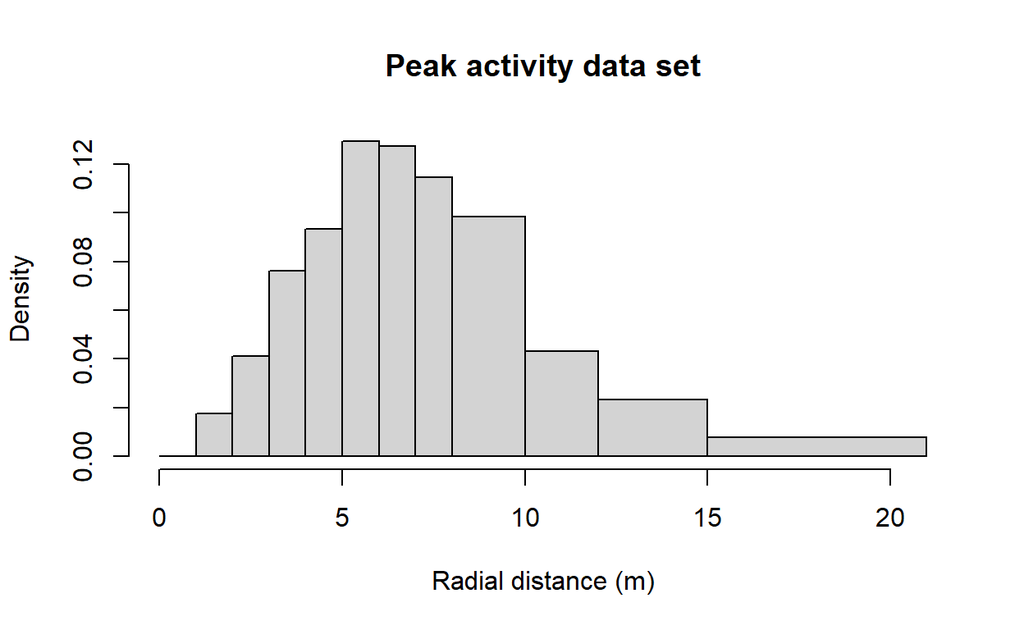

```r
breakpoints <- c(seq(0,8,1), 10, 12, 15, 21)
hist(DuikerCameraTraps$distance, breaks=breakpoints, main="Peak activity data set",
     xlab="Radial distance (m)")
```

## Truncation decisions

As described by Howe et al. (2017):

> a paucity of observations between 1 and 2 m but not between 2 and 3 m, so we left-truncated at 2 m. Fitted detection functions and probability density functions were heavy-tailed when distances >15 m were included, so we right truncated at 15 m.

# Detection function fits

```r
conversion <- convert_units("meter", NULL, "square kilometer")
trunc.list <- list(left=2, right=15)
mybreaks <- c(seq(2,8,1), 10, 12, 15)
hn0 <- ds(DuikerCameraTraps, transect = "point", key="hn", adjustment = NULL,
          cutpoints = mybreaks, truncation = trunc.list, convert_units = conversion)
hn1 <- ds(DuikerCameraTraps, transect = "point", key="hn", adjustment = "herm",
          nadj=1,
          cutpoints = mybreaks, truncation = trunc.list, convert_units = conversion)
hn2 <- ds(DuikerCameraTraps, transect = "point", key="hn", adjustment = "herm",
          nadj=2,
          cutpoints = mybreaks, truncation = trunc.list, convert_units = conversion)

uni1 <- ds(DuikerCameraTraps, transect = "point", key="unif", adjustment = "cos",
           nadj=1,
           cutpoints = mybreaks, truncation = trunc.list, convert_units = conversion)
uni2 <- ds(DuikerCameraTraps, transect = "point", key="unif", adjustment = "cos",
           nadj=2,
           cutpoints = mybreaks, truncation = trunc.list, convert_units = conversion)

hr0 <- ds(DuikerCameraTraps, transect = "point", key="hr", adjustment = NULL,
          cutpoints = mybreaks, truncation = trunc.list, convert_units = conversion)
hr1 <- ds(DuikerCameraTraps, transect = "point", key="hr", adjustment = "cos",
          nadj=1,
          cutpoints = mybreaks, truncation = trunc.list, convert_units = conversion)
hr2 <- ds(DuikerCameraTraps, transect = "point", key="hr", adjustment = "cos",
          nadj=2,
          cutpoints = mybreaks, truncation = trunc.list, convert_units = conversion)
```

# Preliminary model assessment

Summary of goodness of fit and AIC scores among fitted models.

```r
knitr::kable(summarize_ds_models(hn0,hn1,hn2,uni1,uni2,hr0,hr1,hr2),
             caption="Summary of fitted models", row.names = FALSE,
             digits = c(0,0,0,5,3,4,1))
```

Table 1: Summary of fitted models

| Model | Key function | Formula | $\chi^2$ $p$-value | $\hat{P_a}$ | se($\hat{P_a}$) | $\Delta$AIC |
| --- | --- | --- | --- | --- | --- | --- |
|  | Hazard-rate | ~1 | 0 | 0.398 | 0.0058 | 0.0 |
|  | Hazard-rate with cosine adjustment term of order 2 | ~1 | 0 | 0.398 | 0.0264 | 2.0 |
|  | Hazard-rate with cosine adjustment terms of order 2,3 | ~1 | 0 | 0.398 | 0.0381 | 4.0 |
|  | Half-normal with Hermite polynomial adjustment term of order 4 | ~1 | 0 | 0.345 | 0.0185 | 67.0 |
|  | Half-normal with Hermite polynomial adjustment terms of order 4,6 | ~1 | 0 | 0.348 | 0.0247 | 68.4 |
|  | Uniform with cosine adjustment terms of order 1,2 | NA | 0 | 0.317 | 0.0095 | 118.2 |
|  | Uniform with cosine adjustment term of order 1 | NA | 0 | 0.300 | 0.0022 | 119.8 |
|  | Half-normal | ~1 | 0 | 0.262 | 0.0046 | 204.0 |

# Questions

- What might be justification for left truncation?
  - If animals close to the detector respond, detections (or lack thereof) may not be representative of the detection process. Similarly, if the *vertical* field of view of the detectors do not detect animals short in stature close to the detector, then left truncation might be justified.
  - What are the dangers of such truncation?
    - The truncation distance is subjective. Remember it is detections at small distances that are fundamental to estimating $\hat{h}(0)$: slope of the PDF at distance 0. This estimate is estimated via extrapolation when left truncation is used.
- Initial assessment of fit of models?
  - Note in the *summary table* the P-values for all goodness of fit tests is effectively zero, meaning none of the models fit the data because of overdispersion.
- Preliminary model choice?
  - Using traditional AIC for model selection, we would conclude that the hazard rate model without adjustments is the best of the candidate models for these data.

# Store intermediate results for further analysis in subsequent practicals

```r
fittedmodels <- c("hn0", "hn1", "hn2", "uni1", "uni2", "hr0", "hr1", "hr2")
save(list=fittedmodels, file="duikermodels.RData")
```

Howe, E. J., Buckland, S. T., Després-Einspenner, M.-L., & Kühl, H. S. (2017). Distance sampling with camera traps. *Methods in Ecology and Evolution*, *8*(11), 1558–1565. https://doi.org/10.1111/2041-210X.12790

Howe, E. J., Buckland, S. T., Després-Einspenner, M.-L., & Kühl, H. S. (2018). *Data from: Distance sampling with camera traps*. https://doi.org/10.5061/dryad.b4c70

Miller, D., Rexstad, E., Thomas, L., Marshall, L., & Laake, J. (2019). Distance sampling in R. *Journal of Statistical Software, Articles*, *89*(1), 1–28. https://doi.org/10.18637/jss.v089.i01